# Descriptive Statistics II

06/21/2022

## Descriptive Statistics

- Type of data:
  - Quantitative variables: Whole or real numbered data
    - e.g. Age, BMI
  - Categorical variables: Falls into mutually exclusive categories
    - May or may not have a natural ordering (nominal vs. ordinal)
    - e.g. Biological sex, Race/ethnicity, Education level
- Typical goal in data analysis is understanding the relationship (associations) between pairs of variables.
- Today we’ll focus on bivariate descriptive statistics
- Bivariate descriptive statistics can provide initial clues about associations

## CHS data

```r
# Read-in data
chs = read.csv('CHS_cohortE_final_subset.csv')
str(chs) # Look at structure of the data
```

```
## 'data.frame':    1000 obs. of  26 variables:
##  $ id          : int  54577 50863 52081 53817 54683 55339 55766 51056 54919 52992 ...
##  $ townabbr    : chr  "SA" "SD" "SD" "RV" ...
##  $ age         : num  15.1 16.5 15.6 15.2 14.2 15.2 15.8 16 15.2 16.1 ...
##  $ male        : int  1 1 0 1 1 0 1 1 0 0 ...
##  $ race        : chr  "Others" "Mixed" "Caucasian" "Unknown or Missing" ...
##  $ hisp        : chr  "Hispanic" "Hispanic" "Non-Hispanic" "Hispanic" ...
##  $ asthma      : int  0 NA 0 0 1 0 0 1 0 0 ...
##  $ height      : int  168 168 167 160 169 161 185 183 163 165 ...
##  $ weight      : num  52 50.2 55.6 60.9 62.1 ...
##  $ bmi         : num  18.4 17.8 19.9 23.8 21.8 20.6 33.2 39 28.6 28.4 ...
##  $ educ        : int  1 1 3 2 5 5 2 3 1 2 ...
##  $ HomeBuilt   : chr  "1980 or later" "Unknown or Missing" "1960s to 1970s" "Unknown or Missing" ...
##  $ BaseGasstove: int  1 0 1 1 1 0 1 1 1 1 ...
##  $ BasePets    : int  1 0 1 0 1 1 1 1 1 0 ...
##  $ ETS_base    : int  0 0 0 0 0 0 0 1 0 0 ...
##  $ wheeze      : int  0 NA 0 0 0 0 0 0 0 0 ...
##  $ fev1        : int  4090 3790 3240 3890 3730 3530 5420 4480 3290 3390 ...
##  $ fvc         : int  4950 4810 3370 4190 4930 4010 6360 5590 3450 3930 ...
##  $ pm25        : num  8.84 14.28 15 15.76 14.18 ...
##  $ sulfate     : num  0.93 1.38 1.46 1.57 1.32 ...
##  $ nitrate     : num  1.87 2.28 2.48 2.45 2.18 ...
##  $ ec          : num  0.702 0.873 0.884 0.762 0.893 ...
##  $ dust        : num  0.449 1.302 1.246 1.29 1.34 ...
##  $ longitude   : num  -120 -118 -118 -117 -118 ...
##  $ latitude    : num  34.5 34.1 34.1 34 34.1 ...
##  $ obesity     : logi  FALSE FALSE FALSE FALSE FALSE FALSE ...
```

## Univariate data: Quantitative

Graphical summary: Histogram / Box Plot

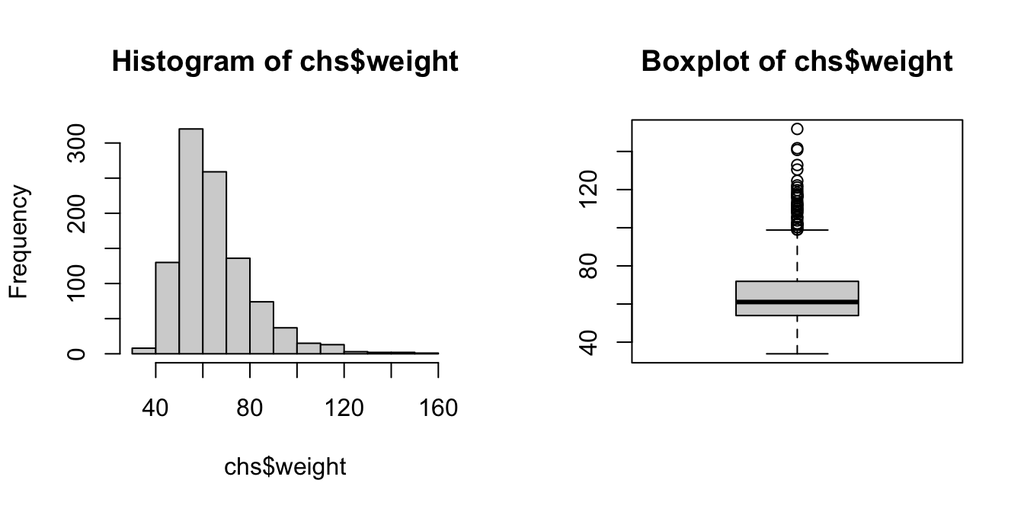

```r
par(mfrow = c(1,2))
hist(chs$weight)
boxplot(chs$weight, main = "Boxplot of chs$weight")
```

## Univariate data: Quantitative

Numerical summary: Mean (sd) / Median (IQR)

```r
mean(chs$weight); sd(chs$weight)
```

```
## [1] 64.6804
```

```
## [1] 15.99024
```

```r
median(chs$weight); IQR(chs$weight)
```

```
## [1] 61.05
```

```
## [1] 17.925
```

## Univariate data: Categorical

Graphical summary: Bar chart (or pie chart)

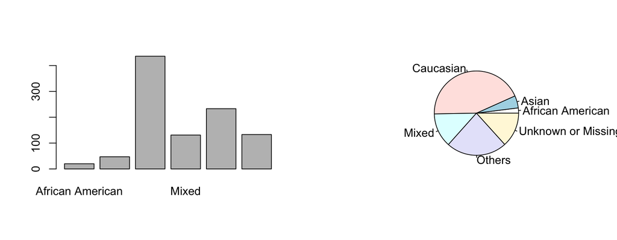

```r
slices <- table(chs$race) # Get counts per race/ethnicity
lbls   <- names(slices) # Get labels
par(mfrow = c(1,2))

barplot(slices)
pie(slices, labels = lbls)
```

## Univariate data: Categorical

Numerical summary: Table of counts / proportions

```r
table(chs$race)
```

```
##
##   African American              Asian          Caucasian              Mixed
##                 20                 47                436                131
##             Others Unknown or Missing
##                233                133
```

```r
prop.table(table(chs$race))
```

```
##
##   African American              Asian          Caucasian              Mixed
##              0.020              0.047              0.436              0.131
##             Others Unknown or Missing
##              0.233              0.133
```

## Quantitative vs. quantitative variables

Graphical summary: scatter plots

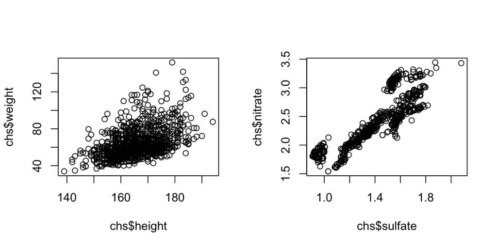

```r
par(mfrow = c(1,2))
plot(chs$height, chs$weight)
plot(chs$sulfate, chs$nitrate)
```

Many R packages for generating plots. **ggplot2** is among the most popular.

## Quantitative vs. quantitative

Numerical summary: Pearson correlation coefficient

\(r = corr(x,y) = \frac{\sum_{i=1}^n (x_i - \bar{x}) (y_i - \bar{y})}{sd(x)sd(y)}\)

\(-1 \le r \le 1\)

Captures strength of *linear* relationship between \(x\) and \(y\)

```r
cor(chs$height, chs$weight)
```

```
## [1] 0.450752
```

```r
cor(chs$sulfate, chs$nitrate)
```

```
## [1] 0.8643069
```

## Quantitative vs. quantitative

```r
x <- seq(-1, 1, by = 0.1)
y <- x^2
cor(y, x) # Close to 0 even if there is a relationship
```

```
## [1] 1.216307e-16
```

## Quantitative vs. quantitative

Correlation examples

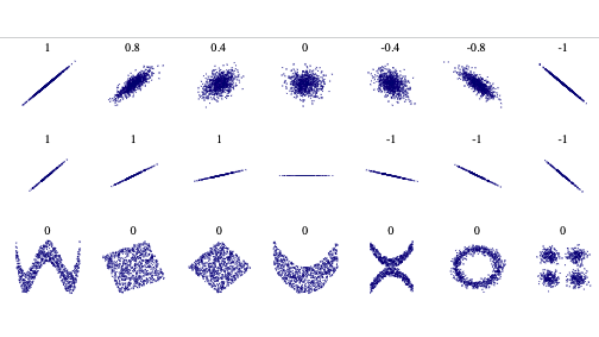

Source: Wikipedia

## Quantitative vs. quantitative

Other measures of correlation exist:

- Spearman’s \(\rho\)
- Kendall’s \(\tau\)

These measures do not require an assumption on linearity but oftentimes have their own assumptions. For example, Spearman’s \(\rho\) captures monotonicity.

## Correlation vs. Causation

Correlation does not imply causation!!!

http://www.tylervigen.com/spurious-correlations

## Quantitative vs. categorical

Graphical summary: Box Plots

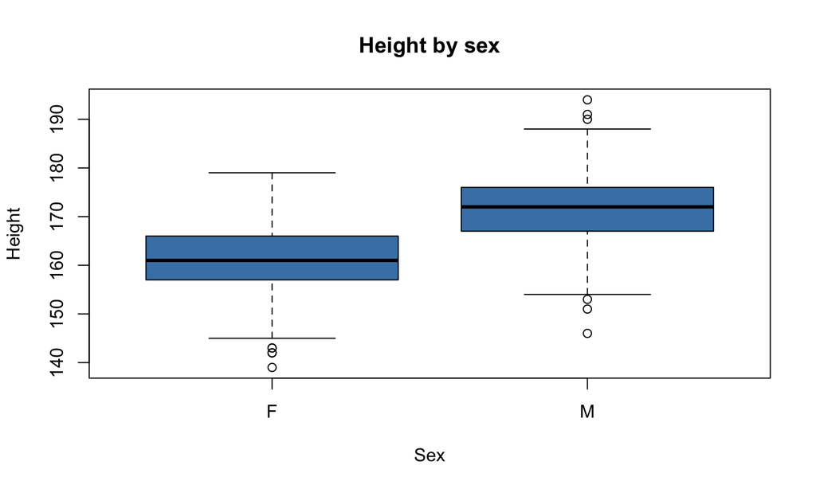

```r
chs$sex = factor(chs$male, levels = 0:1, labels = c('F', 'M'))
boxplot(chs$height ~ chs$sex, main = 'Height by sex',
        xlab = 'Sex', ylab='Height', col = 'steelblue')
```

## Quantitative vs. categorical

Numerical summary: mean/sd or median/IQR **by** levels of the categorical variable

```r
aggregate(chs$height, by = list(chs$sex), FUN=mean)
```

```
##   Group.1        x
## 1       F 161.2863
## 2       M 171.4741
```

```r
aggregate(chs$height, by = list(chs$sex), FUN=sd)
```

```
##   Group.1        x
## 1       F 6.657984
## 2       M 7.192727
```

How to compare the two groups?

## Categorical vs. categorical

Graphical summary: Mosaic plots

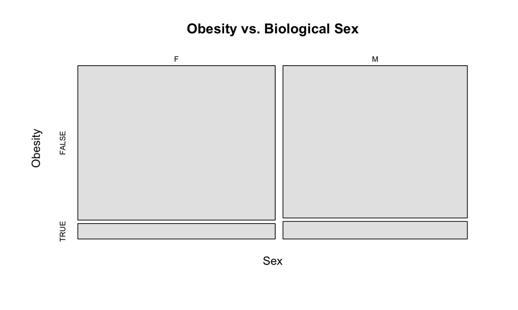

```r
mosaicplot(chs$sex ~ chs$obesity, na.action = na.omit, ylab ='Obesity',
           xlab = 'Sex', col='gray90', main = 'Obesity vs. Biological Sex')
```

## Categorical vs. categorical

Numerical summary: \(2 \times 2\) table

```r
table(chs$sex); table(chs$obesity)
```

```
##
##   F   M
## 517 483
```

```
##
## FALSE  TRUE
##   903    97
```

```r
table(chs$sex, chs$obesity, useNA = "no")
```

```
##
##     FALSE TRUE
##   F   470   47
##   M   433   50
```

## Categorical vs. categorical

```r
table(chs$sex, chs$obesity, useNA = "no")
```

```
##
##     FALSE TRUE
##   F   470   47
##   M   433   50
```

```r
prop.table(table(chs$sex, chs$obesity, useNA = "no"))
```

```
##
##     FALSE  TRUE
##   F 0.470 0.047
##   M 0.433 0.050
```

How to compare the two groups?

- Will discuss more about this next week

## Categorical vs. categorical

Can extend to multiple categories

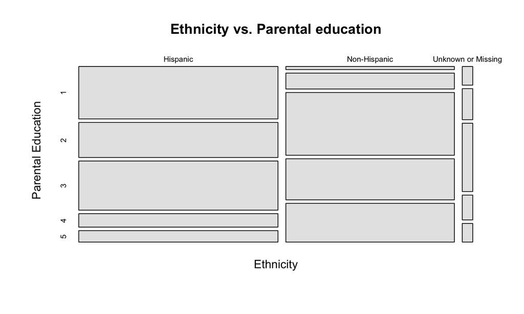

```r
mosaicplot(chs$hisp ~ chs$educ, na.action = na.omit, ylab ='Parental Education',
           xlab = 'Ethnicity', col='gray90', main = 'Ethnicity vs. Parental education')
```

## Categorical vs. categorical

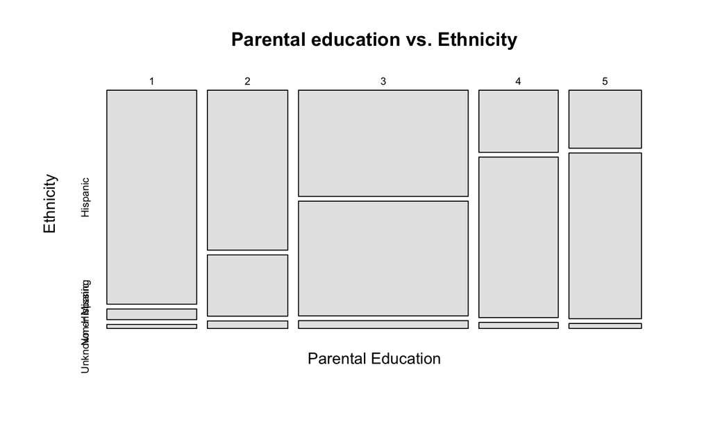

```r
mosaicplot(chs$educ ~ chs$hisp, na.action = na.omit, xlab ='Parental Education',
           ylab = 'Ethnicity', col='gray90', main = 'Parental education vs. Ethnicity')
```

## Categorical vs. categorical

Numerical summary: cross tabulation / contingency table (\(R \times C\) table)

```r
table(chs$educ, chs$hisp)
```

```
##
##     Hispanic Non-Hispanic Unknown or Missing
##   1      160            8                  3
##   2      107           41                  5
##   3      150          162                 11
##   4       41          106                  4
##   5       35          100                  3
```

- The base R `table` function is not great for generating richly-featured crosstabs.
- Many packages: ctabs, xtable, ftable, function `CrossTable` in gmodels, and many more
- Single number summaries are not as obvious for categorical data (will talk about more next week)

## Categorical vs. categorical

Frequency table (by row)

```r
tab <- table(factor(chs$educ), factor(chs$hisp))
round(prop.table(tab, 1), 3)
```

```
##
##     Hispanic Non-Hispanic Unknown or Missing
##   1    0.936        0.047              0.018
##   2    0.699        0.268              0.033
##   3    0.464        0.502              0.034
##   4    0.272        0.702              0.026
##   5    0.254        0.725              0.022
```

## Categorical vs. categorical

Frequency table (by column)

```r
round(prop.table(tab, 2), 3)
```

```
##
##     Hispanic Non-Hispanic Unknown or Missing
##   1    0.325        0.019              0.115
##   2    0.217        0.098              0.192
##   3    0.304        0.388              0.423
##   4    0.083        0.254              0.154
##   5    0.071        0.240              0.115
```

## Parting Comments

- Assessing bivariate associations is a good preliminary step towards a thoughtful analysis.
- These associations can be both quantified and tested for statistical significance (hypothesis testing)
- More sophisticated methods (regression modeling) can be used to assess associations adjusting for other variables.
  - e.g. How does gender affect height after adjusting for age and race/ethnicity?

## Parting Comments

- Data can be presented in various formats
- Clarity is important when communicating and summarizing data through graphs and tables.
  - Less is more
  - Niemi J. and Gelman A. (2011) Statistical Graphics – Making Information Clear and Beautiful. Significance. DOI:10.1111/j.1740-9713.2011.00512.x

## Parting Comments

Several R packages have been developed recently that have improved data wrangling/cleaning and visualization.

- See e.g. `tidyverse` which include both `dplyr` and `ggplot2`.

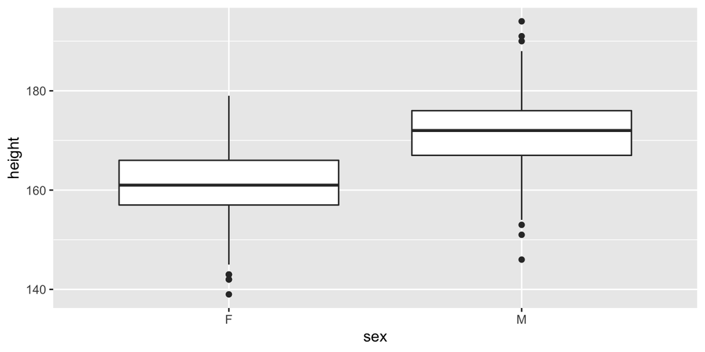

```r
# ggplot2 package
ggplot(aes(x = sex, y = height), data = chs) +
  geom_boxplot()
```